# Activity: Popular Names

Mysha Nihal

06/06/2023

# Set Up

```r
# load necessary packages
library(tidyverse)
library(mosaic)
library(esquisse)


# Load the BabyNames data into RStudio environment (from dcData package)
data("BabyNames", package = "dcData")
```

# Activity

### Step 1

Variables: Name, Sex, Count, Year.

A case refers to a specific combination of values for the variables.

### Step 2

[This should be done by hand on paper, nothing to show in the HTML doc]

### Step 3

##### What variable(s) from the raw data table do not appear at all in the graph?

The variable “sex”.

##### What variable(s) in the graph are similar to corresponding variables in the raw data table, but might have been transformed in some way?

The variable “year” is similar to the corresponding variable in the raw data table, but has been transformed to represent the x-axis values in the graph.

### Step 4

##### Have cases been grouped and summarized within groups in any way?

Cases have been grouped by year and name, and the total number of births per year for each name has been counted regardless of sex.

##### Have any new variables been introduced? If so, what the relationship between the new variables and existing variables?

The new variables introduced are “total” which represents the total number of births per year for each name (regardless of sex).

### Step 5

```r
filtered_data <- BabyNames %>%
  filter(name %in% c("Emma", "Minnie", "Omar", "Rose", "Gregory"))
grouped_data <- filtered_data %>%
  group_by(year, name) %>%
  summarise(TotalBirths = sum(count), .groups = "drop")
grouped_data
```

| year | name | TotalBirths |
| --- | --- | --- |
| 1880 | Emma | 2013 |
| 1880 | Gregory | 5 |
| 1880 | Minnie | 1755 |
| 1880 | Omar | 14 |
| 1880 | Rose | 707 |
| 1881 | Emma | 2043 |
| 1881 | Gregory | 6 |
| 1881 | Minnie | 1661 |
| 1881 | Omar | 11 |
| 1881 | Rose | 734 |

[output cut: 656 more lines]

```r
NA
```

### Step 6

[This should be done by hand on paper, nothing to show in the HTML doc]

### Step 7

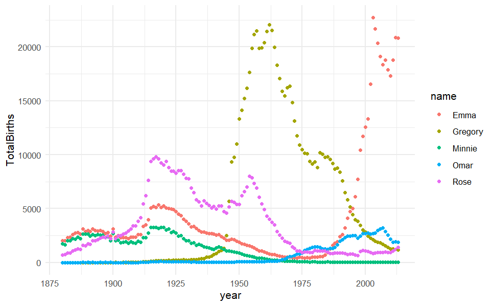

```r
ggplot(grouped_data) +
  aes(x = year, y = TotalBirths, colour = name) +
  geom_point(shape = "circle small", size = 1.5) +
  scale_color_hue(direction = 1) +
  theme_minimal()
```